# Coursera Capstone - Milestone Report

Brandon Robinson

2024-08-18

## Overview

The goal of this project is just to display that you’ve gotten used to working with the data and that you are on track to create your prediction algorithm. This document should be concise and explain only the major features of the data you have identified and briefly summarize your plans for creating the prediction algorithm and Shiny app in a way that would be understandable to a non-data scientist manager.

The model will be trained using a document corpus compiled from the following:

1. Blogs
2. News
3. Twitter

Since the text data has 4 different languages, the project will focus on English.

## Setup and load data

First, the workspace will be setup for the exploratory analysis.

```r
library(knitr)
# disable scientific notation for numbers
options(scipen = 1)
gc()
```

```
##           used (Mb) gc trigger (Mb) max used (Mb)
## Ncells  549861 29.4    1220908 65.3   700245 37.4
## Vcells 1020285  7.8    8388608 64.0  1963326 15.0
```

Download, unzip, and load the training data

### Loading Data

```r
trainURL <- "https://d396qusza40orc.cloudfront.net/dsscapstone/dataset/Coursera-SwiftKey.zip"
trainDataFile <- "data/Coursera-SwiftKey.zip"

if (!file.exists('data')) {
    dir.create('data')
}

if (!file.exists("data/final/en_US")) {
    tempFile <- tempfile()
    download.file(trainURL, tempFile)
    unzip(tempFile, exdir = "data")
    unlink(tempFile)
}

# blogs
blogsFile <- "data/final/en_US/en_US.blogs.txt"
con <- file(blogsFile, open = "r")
blogs <- readLines(con, encoding = "UTF-8", skipNul = TRUE)
close(con)

# news
newsFile <- "data/final/en_US/en_US.news.txt"
con <- file(newsFile, open = "r")
news <- readLines(con, encoding = "UTF-8", skipNul = TRUE)
close(con)

# twitter
twitterFile <- "data/final/en_US/en_US.twitter.txt"
con <- file(twitterFile, open = "r")
twitter <- readLines(con, encoding = "UTF-8", skipNul = TRUE)
close(con)

rm(con)
```

## Data Summary

Before proceeding with the data cleansing, a brief overview of the data will be presented. This will include information such as size, number of lines and characters, and statistical review of the files.

### Initial Summary

```r
library(stringi)

# file size
fileSizeMB <- round(file.info(c(blogsFile,
                                newsFile,
                                twitterFile))$size / 1024 ^ 2)

# num lines per file
numLines <- sapply(list(blogs, news, twitter), length)
names(numLines) <- c("Blogs", "News", "Twitter")
numLines
```

```
##   Blogs    News Twitter
##  899288 1010242 2360148
```

```r
# num characters per file
numChars <- sapply(list(nchar(blogs), nchar(news), nchar(twitter)), sum)
names(numChars) <- c("Blogs", "News", "Twitter")
numChars
```

```
##     Blogs      News   Twitter
## 206824505 203223159 162096241
```

```r
# num words per file
numWords <- sapply(list(blogs, news, twitter), stri_stats_latex)[4,]
names(numWords) <- c("Blogs", "News", "Twitter")
numWords
```

```
##    Blogs     News  Twitter
## 37570839 34494539 30451170
```

```r
# words per line
wpl <- lapply(list(blogs, news, twitter), function(x) stri_count_words(x))
wplSummary = sapply(list(blogs, news, twitter),
             function(x) summary(stri_count_words(x))[c('Min.', 'Mean', 'Max.')])
rownames(wplSummary) = c('WPL.Min', 'WPL.Mean', 'WPL.Max')
colnames(wplSummary) = c("Blogs", "News", "Twitter")

summTable <- data.frame(
    File = c("en_US.blogs.txt", "en_US.news.txt", "en_US.twitter.txt"),
    FileSize = paste(fileSizeMB, " MB"),
    Lines = numLines,
    Characters = numChars,
    Words = numWords,
    t(rbind(round(wplSummary)))
)

summTable
```

```
##                      File FileSize   Lines Characters    Words WPL.Min WPL.Mean
## Blogs     en_US.blogs.txt  200  MB  899288  206824505 37570839       0       42
## News       en_US.news.txt  196  MB 1010242  203223159 34494539       1       34
## Twitter en_US.twitter.txt  159  MB 2360148  162096241 30451170       1       13
##         WPL.Max
## Blogs      6726
## News       1796
## Twitter      47
```

### Histogram Plots of Words

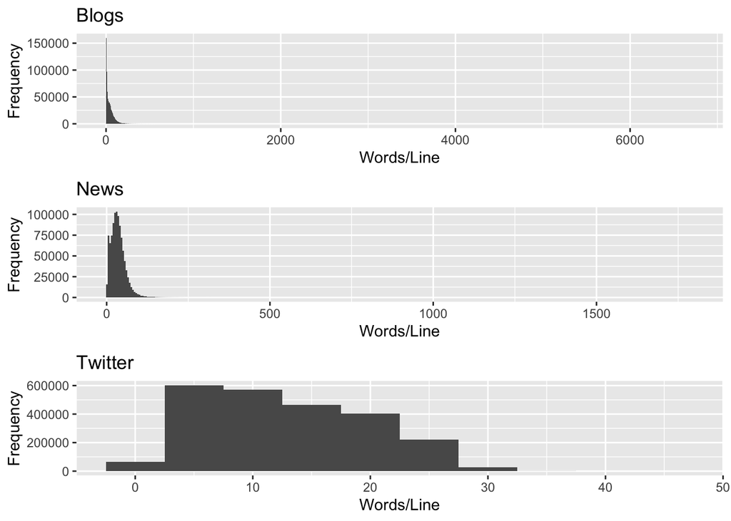

```r
library(ggplot2)
library(gridExtra)

plot1 <- qplot(wpl[[1]], geom = "histogram", main = "Blogs", xlab = "Words/Line",
               ylab = "Frequency",
               binwidth = 5)
plot2 <- qplot(wpl[[2]], geom = "histogram", main = "News", xlab = "Words/Line",
               ylab = "Frequency",
               binwidth = 5)

plot3 <- qplot(wpl[[3]], geom = "histogram", main = "Twitter", xlab = "Words/Line",
               ylab = "Frequency",
               binwidth = 5)

plotList = list(plot1, plot2, plot3)
do.call(grid.arrange, c(plotList, list(ncol = 1)))
```

```r
rm(plot1, plot2, plot3)
```

Similar to the initial analysis, the plots show short concise words. This will be used for the future analysis

## Preparing the data

```r
set.seed(12345)
sampleSize = 0.01

#take a sample of each data set
sampleBlogs <- sample(blogs, length(blogs) * sampleSize, replace = FALSE)
sampleNews <- sample(news, length(news) * sampleSize, replace = FALSE)
sampleTwitter <- sample(twitter, length(twitter) * sampleSize, replace = FALSE)

# remove all non-English characters
sampleBlogs <- iconv(sampleBlogs, "latin1", "ASCII", sub = "")
sampleNews <- iconv(sampleNews, "latin1", "ASCII", sub = "")
sampleTwitter <- iconv(sampleTwitter, "latin1", "ASCII", sub = "")

# combine the data sets
sampleData <- c(sampleBlogs, sampleNews, sampleTwitter)
sampleDataFileName <- "data/final/en_US/en_US.sample.txt"
con <- file(sampleDataFileName, open = "w")
writeLines(sampleData, con)
close(con)

#get number of lines and words, compare with the original table
sampleDataLines <- length(sampleData);
sampleDataWords <- sum(stri_count_words(sampleData))
fileSize2 <- round(file.info(c(sampleDataFileName))$size / 1024 ^ 2)
summTable2 <- data.frame(
    File = c("en_US.sample.txt"),
    FileSize = paste(fileSize2, " MB"),
    Lines = sampleDataLines,
    Words = sampleDataWords
)

summTable
```

```
##                      File FileSize   Lines Characters    Words WPL.Min WPL.Mean
## Blogs     en_US.blogs.txt  200  MB  899288  206824505 37570839       0       42
## News       en_US.news.txt  196  MB 1010242  203223159 34494539       1       34
## Twitter en_US.twitter.txt  159  MB 2360148  162096241 30451170       1       13
##         WPL.Max
## Blogs      6726
## News       1796
## Twitter      47
```

```r
summTable2
```

```
##               File FileSize Lines   Words
## 1 en_US.sample.txt    5  MB 42695 1023329
```

```r
rm(blogs, news, twitter, sampleBlogs, sampleNews, sampleTwitter)
```

The corpus will then be written to disk in two formats: RDS and txt.

> The source code for the corpus and n-gram models are attached as A.1 Build the corpus and A.2 Analysis of the corpus in the Appendix section.

### Analysis of the corpus

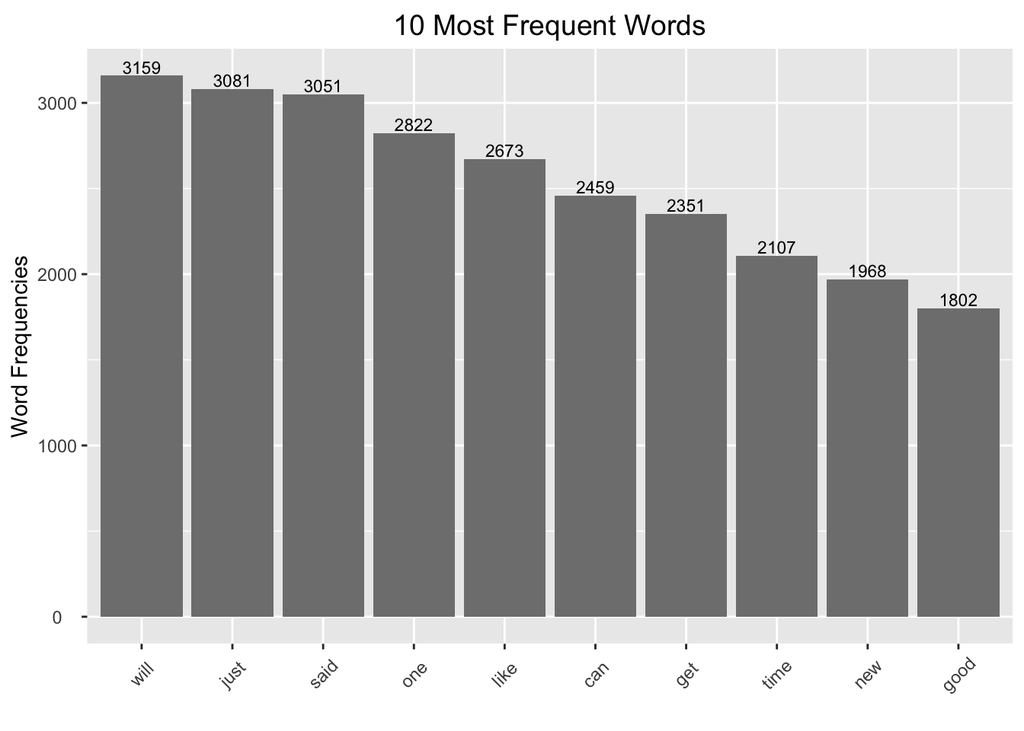

## N-gram Generation

The word prediction model, for the Shiny app, will manage unigrams, bigrams, and trigrams. The `RWeka` package will be used to tokenize the data and build matrices of n-grams

### Unigram

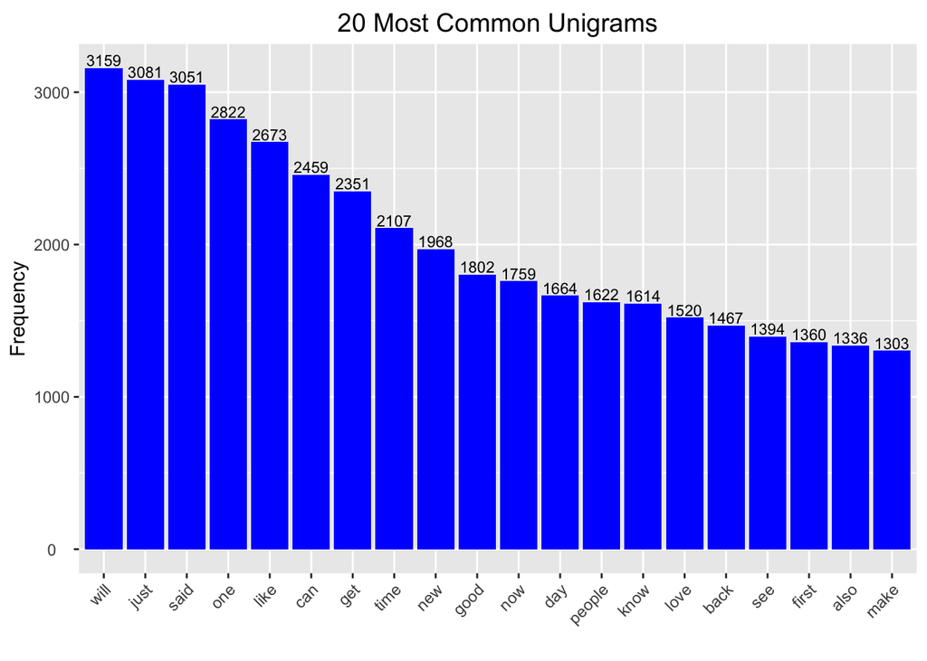

### Bigram

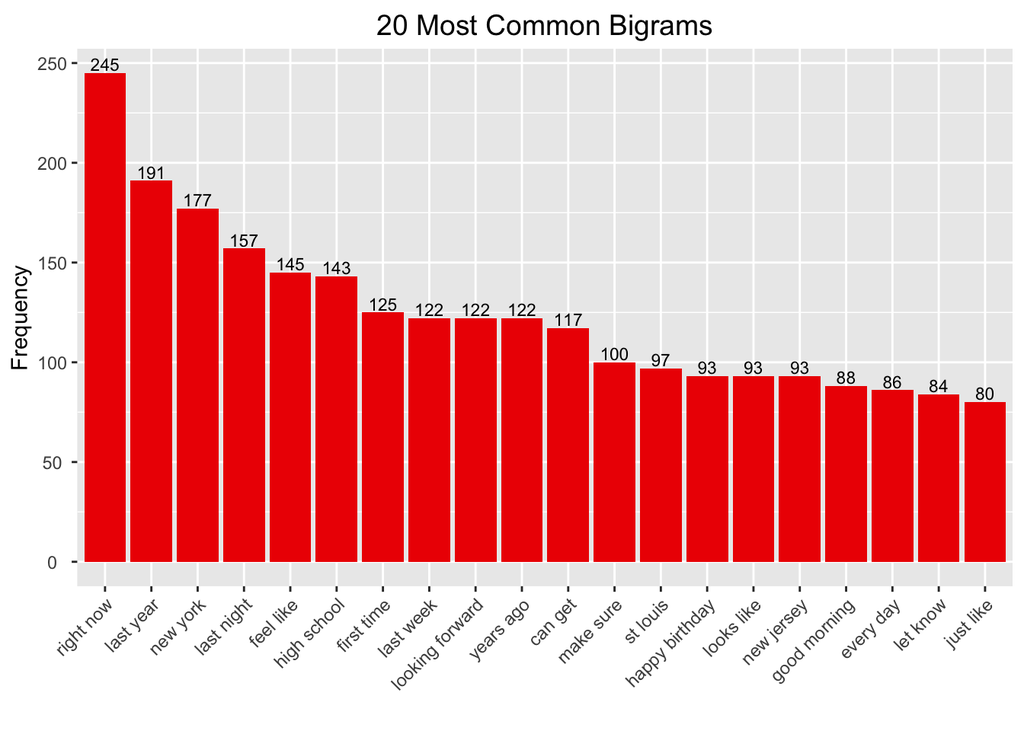

### Trigram

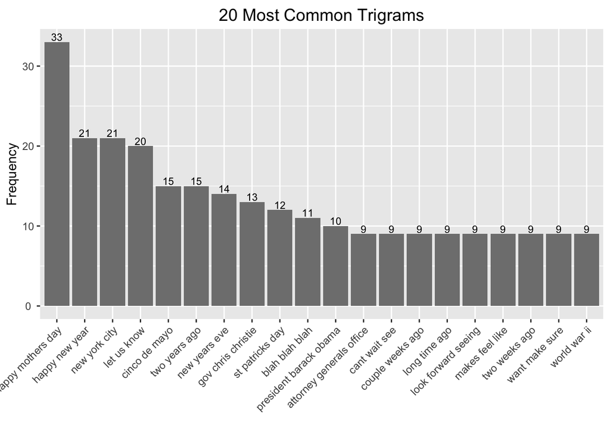

## Conclusion

The next step in the project is to create the Shiny app with a predictive algorithm to take multiple words as an input and predict the next word as an output. The n-gram model shown in this report will be used as the predictive algorithm for the app.

The first strategy will be to successively use each n-gram model starting with trigram. If no match can be found the model will work through bigram and then unigram to find a match.

The next strategy will be to increase efficiency and accuracy overall.

## Appendix

### A.1 Build the corpus

```r
library(tm)

buildCorpus <- function (dataSet) {
    docs <- VCorpus(VectorSource(dataSet))
    toSpace <- content_transformer(function(x, pattern) gsub(pattern, " ", x))

     # remove URL, Twitter handles and email patterns
    docs <- tm_map(docs, toSpace, "(f|ht)tp(s?)://(.*)[.][a-z]+")
    docs <- tm_map(docs, toSpace, "@[^\\s]+")
    docs <- tm_map(docs, toSpace, "\\b[A-Z a-z 0-9._ - ]*[@](.*?)[.]{1,3} \\b")

    docs <- tm_map(docs, tolower)
    docs <- tm_map(docs, removeWords, stopwords("english"))
    docs <- tm_map(docs, removePunctuation)
    docs <- tm_map(docs, removeNumbers)
    docs <- tm_map(docs, stripWhitespace)
    docs <- tm_map(docs, PlainTextDocument)
    return(docs)
}

# build the corpus and write to disk (RDS)
corpus <- buildCorpus(sampleData)
saveRDS(corpus, file = "data/final/en_US/en_US.corpus.rds")

# convert corpus to a dataframe and write lines/words to disk (text)
corpusText <- data.frame(text = unlist(sapply(corpus, '[', "content")), stringsAsFactors = FALSE)
con <- file("data/final/en_US/en_US.corpus.txt", open = "w")
writeLines(corpusText$text, con)
close(con)

rm(sampleData)
```

### A.2 Analysis of the corpus

```r
# Plot the 10 most frequent words
tdm <- TermDocumentMatrix(corpus)
freq <- sort(rowSums(as.matrix(tdm)), decreasing = TRUE)
wordFreq <- data.frame(word = names(freq), freq = freq)

g <- ggplot (wordFreq[1:10,], aes(x = reorder(wordFreq[1:10,]$word, -wordFreq[1:10,]$fre),
                                  y = wordFreq[1:10,]$fre ))
g <- g + geom_bar( stat = "Identity" , fill = I("grey50"))
g <- g + geom_text(aes(label = wordFreq[1:10,]$fre), vjust = -0.20, size = 3)
g <- g + xlab("")
g <- g + ylab("Word Frequencies")
g <- g + theme(plot.title = element_text(size = 14, hjust = 0.5, vjust = 0.5),
               axis.text.x = element_text(hjust = 0.5, vjust = 0.5, angle = 45),
               axis.text.y = element_text(hjust = 0.5, vjust = 0.5))
g <- g + ggtitle("10 Most Frequent Words")
print(g)
```

**Tokenize Functions**

```r
library(RWeka)

unigramTokenizer <- function(x) NGramTokenizer(x, Weka_control(min = 1, max = 1))
bigramTokenizer <- function(x) NGramTokenizer(x, Weka_control(min = 2, max = 2))
trigramTokenizer <- function(x) NGramTokenizer(x, Weka_control(min = 3, max = 3))
```

**Unigrams**

```r
# create term document matrix
unigramMatrix <- TermDocumentMatrix(corpus, control = list(tokenize = unigramTokenizer))

# eliminate sparse terms and get frequencies of most common n-grams
unigramMatrixFreq <- sort(rowSums(as.matrix(removeSparseTerms(unigramMatrix, 0.99))), decreasing = TRUE)
unigramMatrixFreq <- data.frame(word = names(unigramMatrixFreq), freq = unigramMatrixFreq)

# generate plot
g <- ggplot(unigramMatrixFreq[1:20,], aes(x = reorder(word, -freq), y = freq))
g <- g + geom_bar(stat = "identity", fill = I("blue"))
g <- g + geom_text(aes(label = freq ), vjust = -0.20, size = 3)
g <- g + xlab("")
g <- g + ylab("Frequency")
g <- g + theme(plot.title = element_text(size = 14, hjust = 0.5, vjust = 0.5),
               axis.text.x = element_text(hjust = 1.0, angle = 45),
               axis.text.y = element_text(hjust = 0.5, vjust = 0.5))
g <- g + ggtitle("20 Most Common Unigrams")
print(g)
```

**Bigrams**

```r
# create term document matrix
bigramMatrix <- TermDocumentMatrix(corpus, control = list(tokenize = bigramTokenizer))

# eliminate sparse terms and get frequencies of most common n-grams
bigramMatrixFreq <- sort(rowSums(as.matrix(removeSparseTerms(bigramMatrix, 0.999))), decreasing = TRUE)
bigramMatrixFreq <- data.frame(word = names(bigramMatrixFreq), freq = bigramMatrixFreq)

# generate plot
g <- ggplot(bigramMatrixFreq[1:20,], aes(x = reorder(word, -freq), y = freq))
g <- g + geom_bar(stat = "identity", fill = I("red2"))
g <- g + geom_text(aes(label = freq ), vjust = -0.20, size = 3)
g <- g + xlab("")
g <- g + ylab("Frequency")
g <- g + theme(plot.title = element_text(size = 14, hjust = 0.5, vjust = 0.5),
               axis.text.x = element_text(hjust = 1.0, angle = 45),
               axis.text.y = element_text(hjust = 0.5, vjust = 0.5))
g <- g + ggtitle("20 Most Common Bigrams")
print(g)
```

**Trigrams**

```r
# create term document matrix
trigramMatrix <- TermDocumentMatrix(corpus, control = list(tokenize = trigramTokenizer))

# eliminate sparse terms and get frequencies of most common n-grams
trigramMatrixFreq <- sort(rowSums(as.matrix(removeSparseTerms(trigramMatrix, 0.9999))), decreasing = TRUE)
trigramMatrixFreq <- data.frame(word = names(trigramMatrixFreq), freq = trigramMatrixFreq)

# generate plot
g <- ggplot(trigramMatrixFreq[1:20,], aes(x = reorder(word, -freq), y = freq))
g <- g + geom_bar(stat = "identity", fill = I("grey50"))
g <- g + geom_text(aes(label = freq ), vjust = -0.20, size = 3)
g <- g + xlab("")
g <- g + ylab("Frequency")
g <- g + theme(plot.title = element_text(size = 14, hjust = 0.5, vjust = 0.5),
               axis.text.x = element_text(hjust = 1.0, angle = 45),
               axis.text.y = element_text(hjust = 0.5, vjust = 0.5))
g <- g + ggtitle("20 Most Common Trigrams")
print(g)
```